# 💰 Big picture: Olist Financials

[interactive chart not shown]

# ❓ How to handle under-performing sellers to increase profit?

## 🕵️ What is an under-performing seller?

👉 There are **2967** sellers on Olist

🔎 Insights on the **profits** they generate **for Olist**

👉 **376 (12.6%)** of them generate a **negative profit**

👉 Profits across sellers from **-21k** to **18k** BRL

👉 The average profit per seller is **393** BRL

👉 **50%** of sellers generate at least a profit of **254** BRL

👉 **25%** of sellers generate a profit inferior to **30** BRL

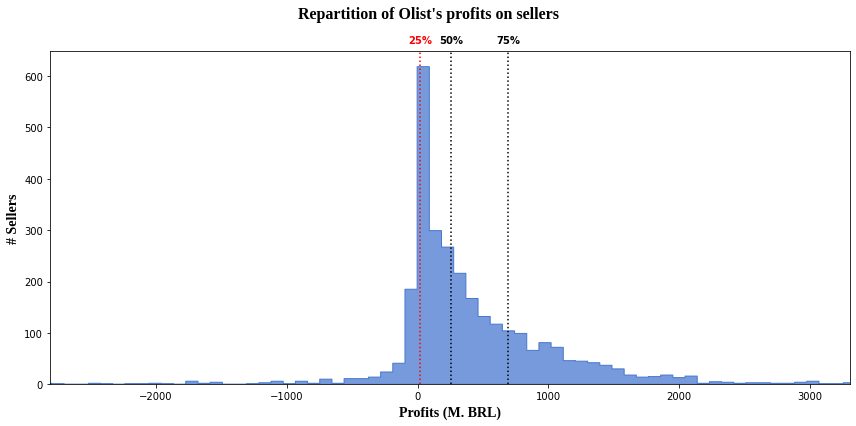

🎯 For reference, we will consider the **742** sellers that yielded a profit inferior to **30** BRL as **under-performers**

# 🔮 What-if Analysis

### What could Olist have done to increase profits ...

### ... with the information we have now?

### 💡 Let's see the financial impact of **removing sellers**, starting from the **less profitable one**

### 💡 We **rank** the sellers by **increasing profits**, and estimate the **costs** and **revenues** after removing them from Olist over the past 16 months

## Revenues

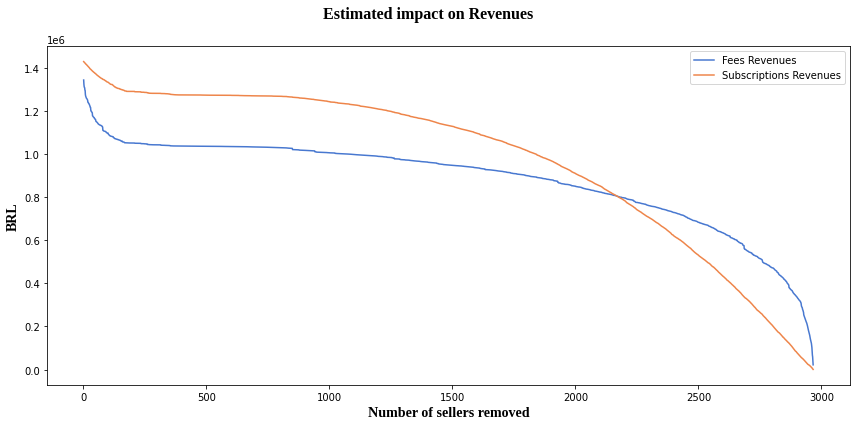

## Costs

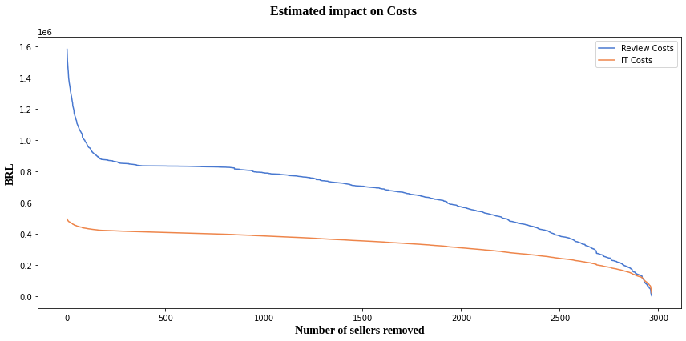

**💡 Removing the less profitable sellers nets a great decrease of the estimated costs of bad reviews**  
**💡 IT Costs seem less relevant to this analysis**

# 🧑‍⚖️ How many under-performers to remove?

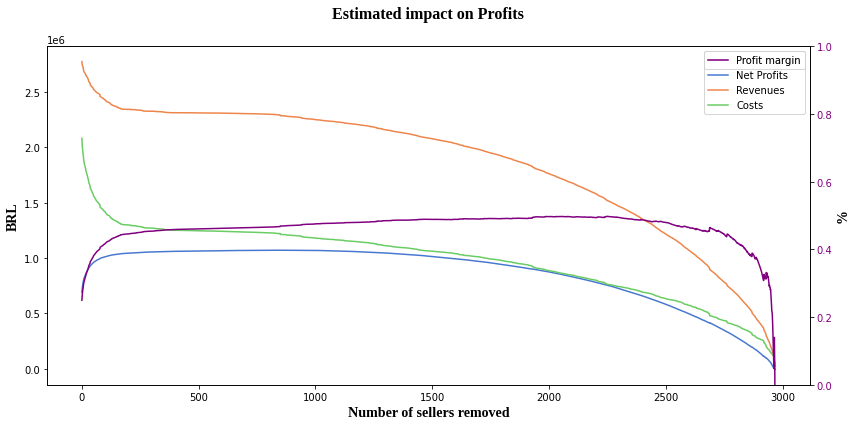

### 📊 Decision thresholds

#### 👉 Optimizing for **profits** requires removing **854 (29%)** sellers

#### 👉 Optimizing for the **profit margin** requires removing **2244 (76%)** sellers

# 🔎 Going further

We should improve this analysis by taking into account the dynamics: **Olist does not know in advance a seller's performance.**

Sellers should only be removed from the platform **after yielding negative profits for a given period.**

🤖 The **Machine Learning** module will help us identify the worst performers early on, stay tuned 😉